# Data challenge

Mathis Cordier

11/01/2020

L’objectif du data challenge est de classer 1000 individus dont on ne connaît pas réellement la classe d’appartenance. Pour cela, nous disposons de 2 jeux de données de 1000 individus et 500 variables. Le premier est la base d’entraînement et le second la base de test. Pour le premier, nous connaissons le résultat réel de la variable à expliquer et l’objectif est de prédire au mieux la variable à expliquer du jeu de données test.

## Méthodes essayées

Avant d’arriver à une méthode de réseaux de neurones, j’ai essayé un grand de nombre de méthodes avec plus ou moins de réussite. Les méthodes Lasso, K-NN et SVM ne semblent a priori pas efficaces sur ce jeu de données. Je n’ai en tout cas pas réussi à trouver un paramétrage qui permettait de passer les 70-75%.

J’ai ensuite passé beaucoup de temps sur les méthodes de forêts aléatoires. D’abord avec les algorithmes de Random Forest puis avec les algorithmes de Gradient Boosting et d’Extrem Gradient Boosting. Parmi ces méthodes qui me permettaient toutes d’atteindre 80% de bonnes prédictions, c’est la méthode de Gradient Boosting qui m’a permis d’obtenir 81.4%, qui a longtemps été mon meilleur résultat. J’ai effectué ces méthodes sous python, exactement à la manière dont c’est expliqué dans l’exercice 1. J’ai alors utilisé successivement la fonction de sklearn GridSearchCV afin d’affiner les paramètres pour obtenir le meilleur modèle possible.

J’ai ensuite essayé les algorithmes de deep learning que j’ai précisé ci-dessous.

## Pre-processing

Premièrement, nous importons les packages dont nous aurons besoin pour l’analyse des données.

Nous importons également les données où X représente la population d’entraînement, Xfin la population à prédire et Y les variables qualitatives à expliquer correspondant à la population d’entraînement.

```r
X = read.csv("Xtrainchallenge.txt",sep=" ")
Y = read.csv("Ytrainchallenge.txt", sep=" ")$x
Xfin = read.csv("Xtestchallenge.txt",sep=" ")
```

Dans le cadre des réseaux de neurones, nous devons normaliser les valeurs, c’est-à-dire que pour chaque variable/colonne, nous transformons les valeurs linéairement pour qu’elles soient entre 0 et 1. De même, pour que le package Keras interprête bien Y, nous devons passer les niveaux de la variable qualitative à 0 et 1. Ici, nous modifions donc simplement les valeurs valant -1 pour qu’elles valent 0.

Maintenant, nous passons à l’étape de séléction de variables. En effet, de part les corrélations présentes entre les variables de X et la très probable présence de variables ne permettant pas d’améliorer notre modèle dans le cadre de notre problème, nous devons sélectionner les variables qui le peuvent. Pour cela, nous utilisons les forêts aléatoires. Elles nous permettent de comptabiliser l’importance de chaque variable en sommant le nombre de fois où chaque variable a été retenue dans les arbres de décision. Nous fixons alors arbitrairement un seuil, là où l’importance des variables semble se démarquer.

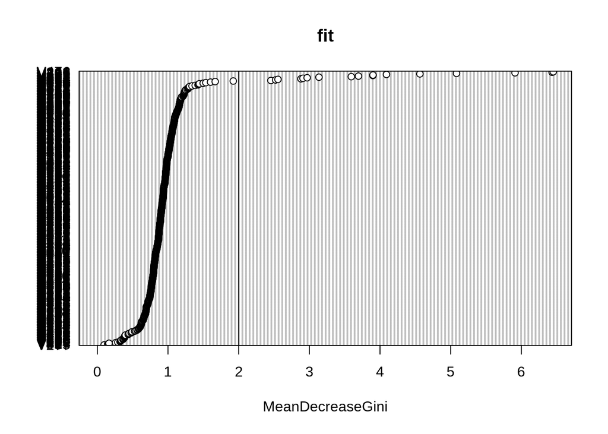

```r
Y_fact = as.factor(Y)
df = data.frame(Y_fact,X)
fit = randomForest(Y_fact~., data=df)
varImpPlot(fit, n.var=500)
sep = 2
abline(v=sep)
```

```r
N = sum(fit$importance>sep)
conserv = which(fit$importance>sep)
X2 = as.matrix(X[,conserv])
Y2 = as.integer(Y)
Xfin2 = as.matrix(Xfin[,conserv])
```

On ne retient alors que les variables importantes. Les autres variables ne joueront pas de rôle donc nous supprimons ces colonnes dans les matrices X et Xfin. Cette méthode implique une perte d’information car nous conservons moins de 5% des variables. Cependant, elle permet à l’algorithme de converger plus rapidement vers un optimum plus stable qu’en utilisant des variables séparant mal les classes.

On retrouve alors les variables sélectionnées sur le graphe suivant.

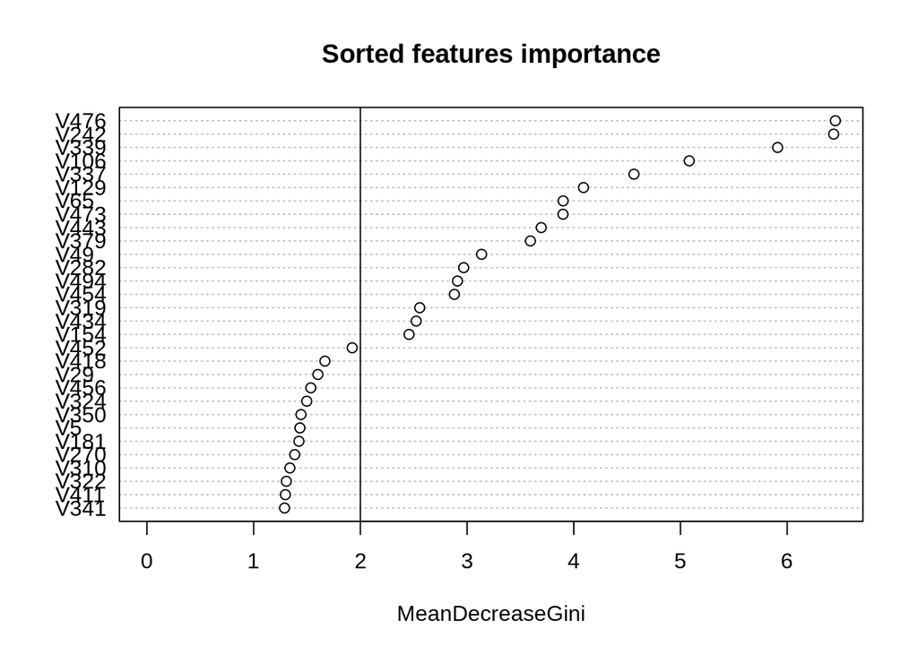

```r
varImpPlot(fit, n.var=30, main="Sorted features importance")
abline(v=sep)
```

## Réseau de neurones

Nous passons alors au perceptron multicouche. Notre modèle est le suivant :

```r
# Perceptron multicouche
model = keras_model_sequential()
model %>%
  layer_dense(units = 300,
              input_shape = N,
              kernel_initializer = "glorot_normal",
              bias_initializer = Constant(0.001),
              activation = "relu") %>%
  layer_dropout(rate=0.5) %>%
  layer_dense(units = 300,
              kernel_initializer = "glorot_normal",
              activation = "relu",
              kernel_regularizer = regularizer_l1_l2(l1=0.0001,l2=0.0001),
              bias_regularizer = regularizer_l1_l2(l1=0.001,l2=0.001)) %>%
  layer_dropout(rate=0.5) %>%
  layer_dense(units = 50,
              activation = "tanh") %>%
  layer_dropout(rate=0.5) %>%
  layer_dense(units = 1, activation = "sigmoid",
              kernel_initializer = "ones")
print(summary(model))
```

```
## Model: "sequential"
## ___________________________________________________________________________
## Layer (type)                     Output Shape                  Param #
## ===========================================================================
## dense (Dense)                    (None, 300)                   5400
## ___________________________________________________________________________
## dropout (Dropout)                (None, 300)                   0
## ___________________________________________________________________________
## dense_1 (Dense)                  (None, 300)                   90300
## ___________________________________________________________________________
## dropout_1 (Dropout)              (None, 300)                   0
## ___________________________________________________________________________
## dense_2 (Dense)                  (None, 50)                    15050
## ___________________________________________________________________________
## dropout_2 (Dropout)              (None, 50)                    0
## ___________________________________________________________________________
## dense_3 (Dense)                  (None, 1)                     51
## ===========================================================================
## Total params: 110,801
## Trainable params: 110,801
## Non-trainable params: 0
## ___________________________________________________________________________
## NULL
```

Les couches de dropout vont servir à limiter le sur-apprentissage en sélectionnant la moitié des neurones à chaque itération. L’autre moitié n’est alors pas utilisée lors de l’itération, cela permet d’améliorer la robustesse du modèle.

Nous définissons ensuite les paramètres de compilation. Nous sommes dans un cas de classification donc la fonction de perte `loss` vaut “binary_crossentropy”, nous choisissons l’algorithme d’optimisation “adam” pour la variable `optimizer` et nous prenons comme métrique la précision pour la variable `metrics`.

```r
model %>%
  compile(loss="binary_crossentropy",
          optimizer="adam",
          metrics="accuracy")
```

Pour entraîner le modèle, nous choisissons de mettre la variable `validation_split` à 25%. Cette variable va en fait séparer la population d’entraînement à chaque itération : 25% sera pris comme population test et ne servira pas à entraîner le modèle. Nous définissons `epocs`, le nombre d’itérations, comme valant 1000 car cela nous permet de converger et d’atteindre notre optimum. Nous définissons également `batch_size`, le nombre d’individus pris de la population d’entraînement à chaque itération, comme valant 750. Nous ne découpons donc pas la base d’entraînement, cela nous permet de minimiser les variations dans l’amélioration du modèle au prix d’un coup de calcul plus important se traduisant par une surcharge de la mémoire et un temps de calcul plus long. En effet, dans le cas d’un algorithme mini-batch où nous parcourons plusieurs portions de la base de données à chaque itération, nous obtenons un temps de calcul plus court et moins coûteux mais avec des variations qui peuvent perturber la descente de gradient quand la valeur de batch_size est trop faible. Nous rajoutons également au paramètre `callbacks` la fonction ReduceLROnPlateau qui va nous permettre de diminuer le `learning_rate` de l’algorithme d’optimisation “adam” lorsque la valeur de `loss`, associée à la partie “test” de la base de données issue de `validation_split`, commence à stagner.

```r
lng_hist = model %>% fit(X2,
                           Y,
                           epochs = 1000,
                           batch_size = 750,
                           validation_split = 0.25,
                           callbacks = list(ReduceLROnPlateau(patience=50,
                                                              factor=0.5)))
```

Nous voulons maintenant étudier les évolutions de notre modèle au fil des itérations. Pour cela nous formons 3 tableaux de données correspondant aux 3 graphiques que vous trouverez ci-dessous, c’est-à-dire, un graphique concernant l’évolution de la fonction de perte, un autre concernant l’évolution du taux de bonnes prédictions et un dernier concernant l’évolution du taux d’apprentissage.

```r
# accuracy evolution
evol_acc = data.frame(cbind(1:1000,lng_hist$metrics$accuracy,lng_hist$metrics$val_accuracy))
colnames(evol_acc) = c("time","train_acc","test_acc")

# loss evolution
evol_loss = data.frame(cbind(1:1000,lng_hist$metrics$loss,lng_hist$metrics$val_loss))
colnames(evol_loss) = c("time","train_loss","test_loss")

# learning rate evolution
evol_lr = data.frame(cbind(1:1000,lng_hist$metrics$lr))
colnames(evol_lr) = c("time","learning_rate")
```

Nous obtenons alors l’évolution suivante pour la fonction de perte :

```r
plot_ly(evol_loss,
        x = ~time,
        y = ~train_loss,
        type = 'scatter',
        mode = 'lines',
        name = "Training loss") %>%
  add_trace(y = ~test_loss,
            type = 'scatter',
            mode = 'lines',
            name = "Testing loss") %>%
  layout(xaxis = list(title="Epochs"),
         yaxis = list(title="Loss"))
```

[interactive chart not shown]

Nous obtenons alors l’évolution suivante pour le taux de prédiction :

```r
plot_ly(evol_acc,
        x = ~time,
        y = ~train_acc,
        type = 'scatter',
        mode = 'lines',
        name = "Training accuracy") %>%
  add_trace(y = ~test_acc,
            type = 'scatter',
            mode = 'lines',
            name = "Testing accuracy") %>%
  layout(xaxis = list(title="Epochs"),
         yaxis = list(title="Accuracy"))
```

[interactive chart not shown]

Nous obtenons alors l’évolution suivante pour le taux d’apprentissage :

```r
plot_ly(evol_lr,
        x = ~time,
        y = ~learning_rate,
        type = 'scatter',
        mode = 'lines',
        name = "learning rate") %>%
  layout(xaxis = list(title="Epochs"),
         yaxis = list(title="Learning rate"))
```

[interactive chart not shown]

Nous pouvons alors maintenant prédire les valeurs correspondant à la population test nommée Xfin.

```r
predfin = model %>%
  predict_classes(Xfin2)
predfin = as.numeric(predfin)
predfin[predfin==0] = -1
print(predfin)
```

```
##    [1] -1 -1  1  1  1 -1  1  1 -1  1 -1 -1 -1  1  1 -1 -1  1  1  1  1  1  1
##   [24] -1  1  1  1  1  1  1  1 -1 -1 -1  1 -1  1  1  1 -1  1  1 -1 -1 -1 -1
##   [47] -1  1 -1 -1 -1  1  1  1  1  1  1 -1  1 -1 -1 -1 -1 -1 -1 -1  1  1  1
##   [70]  1  1 -1 -1  1 -1  1 -1  1 -1  1  1 -1 -1  1 -1 -1 -1 -1  1  1 -1 -1
##   [93] -1  1 -1 -1  1 -1 -1  1 -1  1 -1 -1 -1  1  1 -1 -1 -1  1 -1 -1 -1 -1
##  [116] -1  1 -1  1  1  1 -1 -1 -1 -1 -1 -1  1  1 -1  1  1 -1 -1 -1  1  1 -1
##  [139] -1  1  1 -1 -1  1 -1  1 -1  1  1 -1 -1  1 -1  1  1  1  1  1 -1  1 -1
##  [162] -1 -1 -1 -1 -1 -1 -1 -1 -1 -1  1  1  1 -1 -1  1  1 -1 -1  1 -1 -1  1
##  [185]  1 -1 -1 -1  1  1  1 -1  1  1 -1  1  1  1  1  1 -1  1  1  1 -1 -1 -1
##  [208]  1 -1  1  1  1 -1  1  1 -1 -1 -1 -1 -1 -1 -1 -1  1  1  1 -1  1 -1 -1
##  [231]  1  1  1  1  1 -1  1  1 -1  1  1  1 -1 -1 -1 -1 -1  1 -1  1 -1  1 -1
##  [254]  1  1 -1  1 -1 -1 -1 -1  1  1  1 -1  1  1 -1  1  1 -1  1  1  1 -1  1
##  [277]  1 -1 -1  1 -1  1  1 -1 -1 -1  1  1 -1 -1  1  1 -1  1  1  1 -1  1  1
##  [300]  1 -1  1 -1 -1  1 -1  1  1  1 -1 -1 -1  1 -1 -1  1  1  1 -1 -1 -1 -1
##  [323] -1 -1 -1 -1  1 -1  1  1  1 -1  1 -1 -1  1 -1  1 -1 -1 -1  1 -1  1 -1
```

[output cut: 29 more lines]

Ce modèle permet d’obtenir 86.3% de bonnes prédictions, le meilleur modèle que j’ai pu trouvé en parcourant toutes les méthodes d’apprentissage statistique.

Nous obtenons alors un bon taux de prédiction malgré une possible partie de sur-apprentissage bien que les paramètres de régularisation (notamment du biais) et les couches ‘dropout’ soient bien présents dans le modèle. Des essais de diminution du nombre de couches ou du nombre de neurones par couche n’ont pas permis d’améliorer le taux de bonnes prédictions.